# Sunny skies and angel’s pleas: The words of Sonic Youth

by Dominik Freunberger

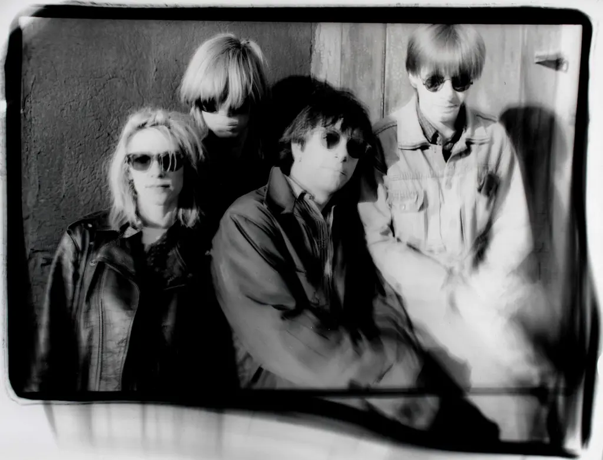

*Can you please pass me a jug of winter light?*  
*Fold me in an ocean’s whim?*  
*In sweet corrosive fire light?*  
*In the city made of tin?*  
*Are you famous under the skin?*  
*Familiar with the things you wanted?*  
*Able now to take it all in?*  
*Making peace with every hole in the story?*  
(From the song [*NYC Ghosts & Flowers*)](https://www.youtube.com/watch?v=bqnkMEnU0iI)

The NYC no wave/noise rock/post punk band **Sonic Youth** is not only known for their eccentric noise landscapes but equally well for their intricate lyrics deeply rooted in the tradition-less tradition of modern American poetry.

Here I will take a deep dive into the words of the band’s 15 studio records between 1983 and 2009.

I’ll get the lyrics from Genius’ API. You need a genius account and create an API client on https://genius.com/api-clients for this.

```r
# enter genius token when prompted:
genius_token()

# Find artist ID for Sonic Youth
artist = search_artist("sonic Youth")
songs = get_artist_songs_df(artist$artist_id)

# Get all song IDs
ids = c(as.character(songs$song_id))

# Create empty dataframe for the lyrics
lyrics = data.frame()

# Add lyrics to df. This takes a long while.
# for (id in ids) {
#   lyrics = rbind(get_lyrics_id(id), lyrics)
#   print(id)
# }

# The loop above crashes after a while for an unknown reason.
# I found the solution below on
# https://www.r-bloggers.com/2021/01/scraping-analysing-and-visualising-lyrics-in-r/
tic()
while (length(ids) > 0) {
  for (id in ids) {
    tryCatch({
      lyrics = rbind(get_lyrics_id(id), lyrics)
      successful = unique(lyrics$song_id)
      ids = ids[!ids %in% successful]
      print(paste("done - ", id))
      print(paste("New length is ", length(ids)))
    }, error = function(e){})
  }
}
toc()

lyrics_raw = lyrics
saveRDS(lyrics_raw, "./interim_data/sonic_youth_lyrics_raw.RDS")

# it get's only 277 of 419 songs listed on Genius; reason unknown. But okej.
# add album info
all_ids = data.frame(song_id = unique(lyrics$song_id))
all_ids$album = ""

for (song in all_ids$song_id) {
  all_ids[match(song,all_ids$song_id),2] = get_song_df(song)[12]
  print(song)
}

# join lyrics with album, year, and lyrics writer id
lyrics = full_join(all_ids, lyrics)

# get rid of unused cols and rename them
lyrics = lyrics %>%
  select(artist_name, album, song_name, song_id, section_name, line) %>%
  rename(artist = artist_name, song = song_name, section = section_name)

saveRDS(lyrics, "./interim/sonic_youth_lyrics_clean.RDS")
```

```r
lyrics %>%
  group_by(album) %>%
  summarize(nr_of_songs = n_distinct(song)) %>%
  arrange(desc(nr_of_songs)) %>%
  kable()
```

| album | nr_of_songs |
| --- | --- |
| Dirty | 15 |
| Experimental Jet Set, Trash and No Star | 14 |
| Daydream Nation | 12 |
| Goo Demos | 12 |
| Rather Ripped | 12 |
| The Eternal | 12 |
| Walls Have Ears | 12 |
| A Thousand Leaves | 11 |
| Goo | 10 |
| Sister | 10 |
| Sonic Nurse | 10 |
| Washing Machine | 10 |
| Confusion Is Sex | 9 |
| EVOL | 8 |
| NYC Ghosts & Flowers | 8 |
| Bad Moon Rising | 7 |
| Murray Street | 7 |
| Sonic Youth EP 2006 Reissue | 6 |
| Dirty - Deluxe Edition | 5 |
| Hold That Tiger | 5 |
| 4 Tunna Brix | 4 |
| The Destroyed Room: B-Sides and Rarities | 4 |
| TV Shit | 4 |
| Goo - Deluxe Edition | 3 |
| Screaming Fields of Sonic Love | 3 |
| SYR 4: Goodbye 20th Century | 3 |
| NA | 3 |
| Helen Lundberg / Eyeliner | 2 |
| Hits Are for Squares | 2 |
| Kill Yr Idols | 2 |
| Made in USA | 2 |
| Master=Dik | 2 |
| New York - Ystad | 2 |
| Nothing Short Of Total War (Part One) | 2 |
| Sonic Death | 2 |
| The Diamond Sea | 2 |
| Bande Originale Du Film Demonlover | 1 |
| Fortune Cookie Prize | 1 |
| Sgt. Pepper Knew My Father | 1 |
| (Over)Kill Yr Idols | 1 |
| Bridge School Concerts: 25th Anniversary Edition | 1 |
| Buddy Series Vol. #1 | 1 |
| Candle EP | 1 |
| Death Valley ’69 | 1 |
| DGC Rarities Volume 1 | 1 |
| Every Band Has A Shonen Knife Who Loves Them | 1 |
| Fast ‘N’ Bulbous | 1 |
| Freedom of Choice: Yesterday’s New Wave Hits As Performed By Today’s Stars | 1 |
| I’m Not There: Original Soundtrack | 1 |
| Index Magazine Sampler | 1 |
| Just Say Noël | 1 |
| Kali Yug Express | 1 |
| Kool Thing | 1 |
| Little Trouble Girl | 1 |
| Lovedolls Superstar | 1 |
| No Alternative | 1 |
| Noise Fest | 1 |
| Not The Spaces You Know, But Between Them | 1 |
| Pay No Mind / Green Light | 1 |
| Sonic Life | 1 |
| Sonic Youth | 1 |
| Speed Trials | 1 |
| Star Power (Acoustic 09 Version) | 1 |
| Stick Me Donna Magick Momma | 1 |
| SubUrbia (Original Motion Picture Soundtrack) | 1 |
| Sunday | 1 |
| SYR 2: Slaapkamers met Slagroom | 1 |
| SYR 3: Invito al Ĉielo | 1 |
| SYR 7: J’Accuse Ted Hughes | 1 |
| SYR 8: Andre Sider af Sonic Youth | 1 |
| The Bridge - A Tribute To Neil Young | 1 |
| The Melting Plot | 1 |
| The Mini Plot | 1 |
| Touch Me I’m Sick/Halloween | 1 |
| Youth Against Fascism | 1 |

```r
studio_albums = lyrics %>%
  group_by(album) %>%
  summarize(nr_of_songs = n_distinct(song)) %>%
  filter(nr_of_songs > 6,
         !album %in% c("Walls Have Ears", "Goo Demos")) %>%
  select(album)

lyrics_studio = lyrics %>%
  filter(album %in% studio_albums$album)

lyrics_studio %>%
  group_by(album) %>%
  summarize(nr_of_songs = n_distinct(song)) %>%
  arrange(nr_of_songs) %>%
  kable()
```

| album | nr_of_songs |
| --- | --- |
| Bad Moon Rising | 7 |
| Murray Street | 7 |
| EVOL | 8 |
| NYC Ghosts & Flowers | 8 |
| Confusion Is Sex | 9 |
| Goo | 10 |
| Sister | 10 |
| Sonic Nurse | 10 |
| Washing Machine | 10 |
| A Thousand Leaves | 11 |
| Daydream Nation | 12 |
| Rather Ripped | 12 |
| The Eternal | 12 |
| Experimental Jet Set, Trash and No Star | 14 |
| Dirty | 15 |

```r
song_meta_info = data.frame()

for (song in unique(lyrics$song_id)) {
  song_meta_info_temp =  data.frame(song_id = song,
                                    album_name = get_song(song)$content$album$name,
                                    year = get_song(song)$content$release_date_for_display,
                                    lyrics_owner_id = get_song(song)$content$lyrics_owner_id)
  song_meta_info = rbind(song_meta_info, song_meta_info_temp)
  print(song)
  rm(song_meta_info_temp)
}
song_meta_info$year = as.numeric(song_meta_info$year)

lyrics_studio = lyrics_studio %>%
  left_join(song_meta_info) %>%
  arrange(year) %>%
  mutate(year = as.numeric(str_sub(year,-4,-1))) %>%
  select(artist, album, year, lyrics_owner_id, song, song_id, line)

# some dates got messed up
lyrics_studio$year[lyrics_studio$album=="Sonic Nurse"] = 2004
lyrics_studio$year[lyrics_studio$album=="Bad Moon Rising"] = 1985
saveRDS(lyrics_studio, "./interim_data/sonic_youth_lyrics_studio_albums.RDS")
```

**Nice!** Sonic Youth’s lyrical style is heavily influenced by poetry, often reminiscent of the Beat Generation and contemporary [American poetry](https://en.wikipedia.org/wiki/American_poetry). But, as singer and guitar player Thurston Moore puts it, [“lyrics really need rhyme to serve the song”.](https://www.theguardian.com/music/2017/apr/09/thurston-moore-sources-of-inspiration-sonic-youth) So it’s not *just* poetry.  
Let’s explore the words in this noise rock landscape!

### Which Sonic Youth album has most words?

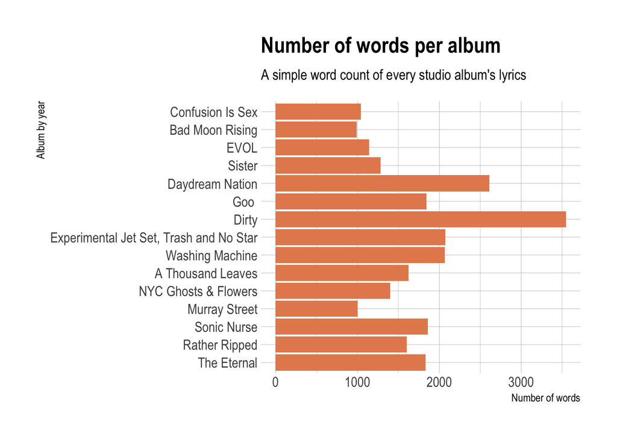

```r
lyrics_studio = readRDS("./interim/sonic_youth_lyrics_studio_albums.RDS")

lyrics_studio %>%
  mutate(words_per_line = sapply(strsplit(line, " "), length)) %>%
  group_by(year, album) %>%
  summarize(number_of_words = sum(words_per_line)) %>%
  ggplot(aes(x = reorder(album, -year), y = number_of_words)) +
  geom_col(fill = punk_colors[3])+
  coord_flip()+
  theme_ipsum() +
  labs(x = "Album by year",
       y = "Number of words",
       title = "Number of words per album",
       subtitle = "A simple word count of every studio album's lyrics")
```

### Repetition and noise: How long are Sonic Youth’s lyrics?

A quick and dirty count of words per song.

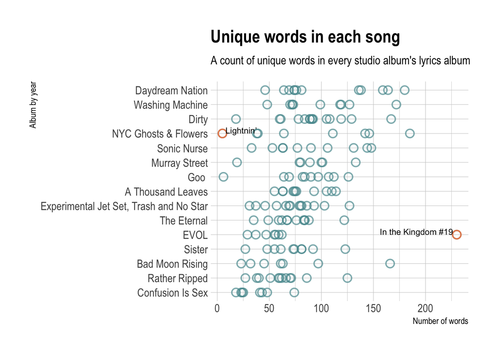

```r
words_per_song = lyrics_studio %>%
  group_by(album, song) %>%
  # paste all the lines per album
  summarize(album_lyrics = paste0(line, collapse = " ")) %>%
  # replace commas (they sometimes have no space afterwards, e.g. test,test)
  mutate(album_lyrics = gsub("\\,", " ", album_lyrics)) %>%
  # lowercase the words
  mutate(album_lyrics = tolower(album_lyrics)) %>%
  # delete special characters
  mutate(album_lyrics = str_replace_all(album_lyrics, "[[:punct:]]", " ")) %>%
  filter(song != "Confusion is Sex - Album Art") %>%
  mutate(unique_words_per_song = sapply(strsplit(album_lyrics, " "), unique)) %>%
  mutate(number_unique_words_per_song = as.numeric(lapply(unique_words_per_song, length))) %>%
  arrange(desc(number_unique_words_per_song))

# let's get the shortest and the longest
short_long = words_per_song %>%
  filter(number_unique_words_per_song > 200 | number_unique_words_per_song < 6)

ggplot(data = words_per_song, aes(x = reorder(album, number_unique_words_per_song), y = number_unique_words_per_song, label = song)) +
  geom_point(shape = 1, size = 3.3, color = punk_colors[5], alpha = 0.7, stroke = 1) +
  geom_point(data = short_long,
             aes(x = reorder(album, number_unique_words_per_song),
                 y = number_unique_words_per_song),
             shape = 1, size = 3.3, color = punk_colors[3], stroke = 1) +
  geom_text(aes(label=ifelse(number_unique_words_per_song<6,as.character(song),'')),hjust=-0.1,vjust=0, size = 3) +
  geom_text(aes(label=ifelse(number_unique_words_per_song>200,as.character(song),'')),hjust=1.05,vjust=0, size = 3) +
  theme(legend.position = "none") +
  coord_flip()+
  theme_ipsum() +
  labs(x = "Album by year",
       y = "Number of words",
       title = "Unique words in each song",
       subtitle = "A count of unique words in every studio album's lyrics album")
```

*Lightning*  
*Lightning strike*  
*Lightning strikes*  
*Lightning strike me*  
*Lightning strikes me*  
*Lightning strike me down*  
*Lightning strikes me down*

(From the song [*Lightning*)](https://www.youtube.com/watch?v=N_64Sh42uW4)

Repetitive lyrics always get me! Five unique words (because we did not stem *strikes* to *strike*, yet)! Though, admittedly, this closing song is clearly an ode to anti-art and rather a convulsion of guitar squeaks and spoken boredom.  
The other end of this spectrum marks the song [*In the Kingdom #19*](https://www.youtube.com/watch?v=jUegc5J8iZk), a gripping [piece of poetry](https://genius.com/Sonic-youth-in-the-kingdom-19-lyrics) with dystopic guitars that seems to be a young descendant of [*Howl*](https://www.poetryfoundation.org/poems/49303/howl). 230 unique words, and, except for the chorus, quite the opposite of repetitiveness.  
Now that we have some ballpark figures about how short or long their lyrics are, let’s have a look at what words they actually use (a lot).

### Which words tho, which words?

```r
# Tokenize the lines
# use what = "word1" so that remove twitter works
lyrics_studio_tokens = tokens(lyrics_studio$line, what = "word1",
                               remove_numbers = TRUE, remove_punct = TRUE,
                               remove_symbols = TRUE, remove_hyphens = TRUE,
                               remove_twitter = TRUE)

# Stem the tokens
lyrics_studio_tokens = tokens_wordstem(lyrics_studio_tokens, language = "english")

# Lowercase the tokens
lyrics_studio_tokens = tokens_tolower(lyrics_studio_tokens)

# Remove stopwords
lyrics_studio_tokens = tokens_remove(lyrics_studio_tokens,
                                      c(stopwords("english"),
                                        smart_stopwords, "you'r"))

# Add bigrams and trigrams to our feature matrix
lyrics_studio_tokens <- tokens_ngrams(lyrics_studio_tokens, n = 1:3)

# Create bag-of-words model (document frequency matrix/ dfm)
lyrics_dfm = dfm(lyrics_studio_tokens, tolower = FALSE)

# calculate frequencies
word_freq = textstat_frequency(lyrics_dfm, n = 200)
```

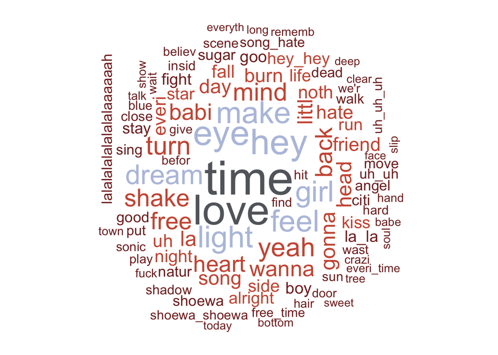

```r
# word cloud with the n most frequent terms
set.seed(42)
wordcloud(words = word_freq$feature,
          freq = word_freq$frequency, max.words = 100,
          random.order = FALSE,
          color = sy_colors)
```

LOVE! DREAM! KISS! FREE! UH UH UH! LALALALALALALALALAAAAAAH! Can’t escape the feeling. And many of the words immediately trigger a song ([*I wish I could be music on a* *tree*](https://www.youtube.com/watch?v=pKlbBgQHPqo)). And the Ohrwurm begins…  
Let’s have a look at Sonic Youth’s most used words and in how many songs are they sung. Note that the words look a bit strange (babi???) because they have been [stemmed](https://en.wikipedia.org/wiki/Stemming).

```r
# word cloud with the n most frequent terms
frequent_words = as.data.frame(word_freq)
frequent_words %>%
  select(feature, frequency, docfreq) %>%
  rename(word = feature, number_of_songs = docfreq) %>%
  top_n(20) %>%
  kable()
```

|  | word | frequency | number_of_songs |
| --- | --- | --- | --- |
| 1 | time | 144 | 130 |
| 2 | love | 124 | 107 |
| 3 | hey | 103 | 66 |
| 4 | eye | 101 | 100 |
| 5 | make | 86 | 85 |
| 6 | light | 85 | 85 |
| 7 | feel | 85 | 84 |
| 8 | girl | 81 | 81 |
| 9 | dream | 75 | 70 |
| 10 | yeah | 71 | 66 |
| 11 | turn | 70 | 68 |
| 12 | mind | 67 | 58 |
| 14 | free | 63 | 51 |
| 15 | back | 62 | 62 |
| 16 | heart | 59 | 59 |
| 17 | babi | 59 | 57 |
| 18 | wanna | 56 | 54 |
| 19 | littl | 53 | 53 |
| 21 | gonna | 53 | 53 |
| 22 | head | 53 | 53 |

### But what are they singin bout? Modeling topics in Sonic Youth’s lyrics.

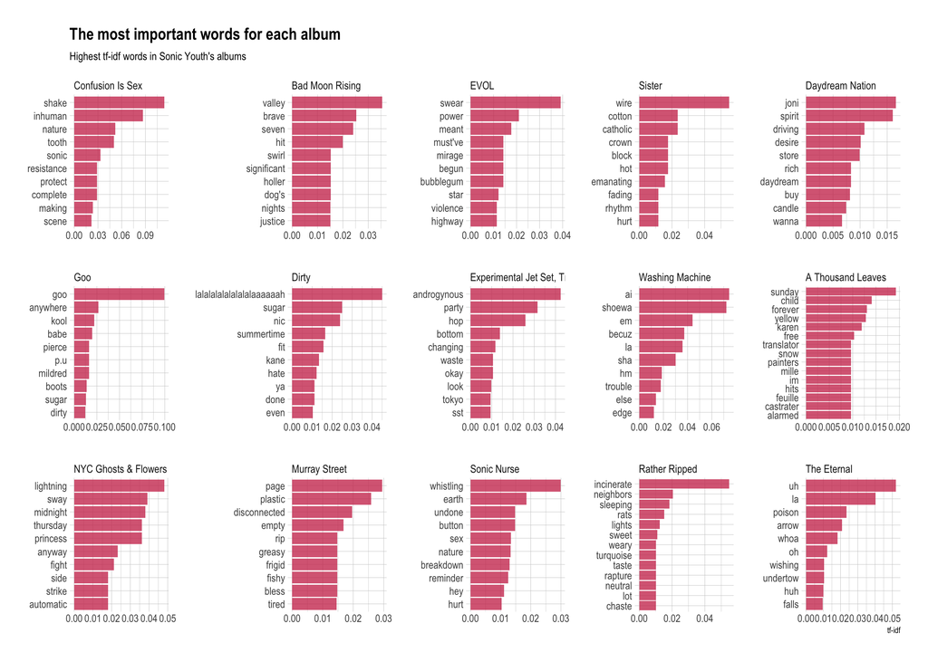

```r
tidy_lyrics = lyrics_studio %>%
  drop_na() %>%
  unnest_tokens(word, line, token = "words") %>%
  anti_join(get_stopwords()) %>%
  filter(!str_detect(word, "[0-9]+")) %>%
  add_count(word) %>%
  select(-n)

lyrics_tf_idf = tidy_lyrics %>%
    count(album, word, sort = TRUE) %>%
    bind_tf_idf(word, album, n) %>%
    arrange(-tf_idf) %>%
    group_by(album) %>%
    top_n(10) %>%
    ungroup

lyrics_tf_idf %>%
    mutate(word = reorder_within(word, tf_idf, album),
           album = factor(album, levels=records_by_year)) %>%
    ggplot(aes(word, tf_idf, fill = album)) +
    geom_col(alpha = 0.8, show.legend = FALSE, fill = punk_colors[2]) +
    facet_wrap(~ album, scales = "free", ncol = 5) +
    scale_x_reordered() +
    coord_flip() +
    theme(strip.text=element_text(size=11)) +
    theme_ipsum()+
    labs(x = NULL, y = "tf-idf",
         title = "The most important words for each album",
         subtitle = "Highest tf-idf words in Sonic Youth's albums")
```